신록예찬's 블로그

# (노트) 드랍아웃, Leaner, CPU vs GPU

Oct 19, 2021 • 신록예찬 • 49 min read

빅데이터분석

```python
import torch
import matplotlib.pyplot as plt
```

```python
torch.manual_seed(5)
X=torch.linspace(0,1,100).reshape(100,1)
y=torch.randn(100).reshape(100,1)*0.01
```

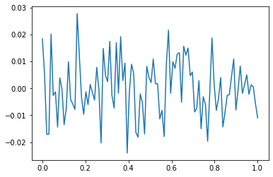

```python
plt.plot(X,y)
```

### 네트워크 설정, 옵티마이저, 로스

```python
torch.manual_seed(1) # 초기가중치를 똑같이..
net= torch.nn.Sequential(
    torch.nn.Linear(1,512),
    torch.nn.ReLU(),
    torch.nn.Linear(512,1))
optimizer= torch.optim.Adam(net.parameters())
loss_fn=torch.nn.MSELoss()
```

### 모형학습

```python
for epoc in range(1000):
    ## 1
    yhat= net(X)
    ## 2
    loss=loss_fn(yhat,y)
    ## 3
    loss.backward()
    ## 4
    optimizer.step()
    net.zero_grad()
```

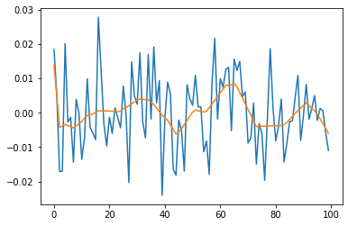

```python
plt.plot(y)
plt.plot(yhat.data)
```

### Train / Validation

```python
X1=X[:80]
y1=y[:80]
X2=X[80:]
y2=y[80:]
```

```python
torch.manual_seed(1) # 초기가중치를 똑같이..
net= torch.nn.Sequential(
    torch.nn.Linear(1,512),
    torch.nn.ReLU(),
    torch.nn.Linear(512,1))
optimizer= torch.optim.Adam(net.parameters())
loss_fn=torch.nn.MSELoss()
```

```python
for epoc in range(1000):
    ## 1
    y1hat= net(X1)
    ## 2
    loss=loss_fn(y1hat,y1)
    ## 3
    loss.backward()
    ## 4
    optimizer.step()
    net.zero_grad()
```

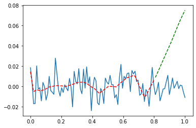

```python
plt.plot(X,y)
plt.plot(X1,y1hat.data,'--r')
plt.plot(X2,net(X2).data,'--g')
```

### 드랍아웃

```python
X1=X[:80]
y1=y[:80]
X2=X[80:]
y2=y[80:]
```

```python
torch.manual_seed(1) # 초기가중치를 똑같이..
net= torch.nn.Sequential(
    torch.nn.Linear(1,512),
    torch.nn.ReLU(),
    torch.nn.Dropout(0.8),
    torch.nn.Linear(512,1))
optimizer= torch.optim.Adam(net.parameters())
loss_fn=torch.nn.MSELoss()
```

```python
for epoc in range(1000):
    ## 1
    y1hat= net(X1)
    ## 2
    loss=loss_fn(y1hat,y1)
    ## 3
    loss.backward()
    ## 4
    optimizer.step()
    net.zero_grad()
```

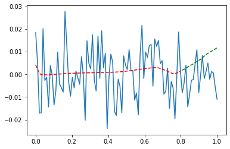

```python
plt.plot(X,y)
net.eval() ## 네트워크 평가모드 전환
plt.plot(X1,net(X1).data,'--r')
net.eval() ## 네트워크 평가모드 전환
plt.plot(X2,net(X2).data,'--g')
```

### 학습과정 비교 (주의: 코드복잡함)

`-` 데이터 생성

```python
torch.manual_seed(5)
X=torch.linspace(0,1,100).reshape(100,1)
y=torch.randn(100).reshape(100,1)
```

`-` tr/val 분리

```python
X_tr=X[:80]
y_tr=y[:80]
X_val=X[80:]
y_val=y[80:]
```

`-` 네트워크, 옵티마이저, 손실함수 설정

- 드랍아웃을 이용한 네트워크 (net2) 와 그렇지 않은 네트워크 설정 (net1)
- 대응하는 옵티마이저 1,2 설정
- 손실함수

```python
torch.manual_seed(1)
net1= torch.nn.Sequential(
    torch.nn.Linear(1,512),
    torch.nn.ReLU(),
    torch.nn.Linear(512,1))
optimizer_net1= torch.optim.Adam(net1.parameters())
net2= torch.nn.Sequential(
    torch.nn.Linear(1,512),
    torch.nn.ReLU(),
    torch.nn.Dropout(0.8),
    torch.nn.Linear(512,1))
optimizer_net2= torch.optim.Adam(net2.parameters())
loss_fn=torch.nn.MSELoss()
```

```python
tr_loss_net1=[]
val_loss_net1=[]
tr_loss_net2=[]
val_loss_net2=[]
```

```python
for epoc in range(1000):
    ## 1. 순방향신경망
    yhat_tr_net1 = net1(X_tr)
    ## 2. 손실함수
    loss_tr = loss_fn(yhat_tr_net1,y_tr)
    ## 3. 미분
    loss_tr.backward()
    ## 4. 업데이트
    optimizer_net1.step()
    net1.zero_grad()
    ## 5. 기록
    ### tr
    tr_loss_net1.append(loss_tr.item())

    ### val
    yhat_val_net1 = net1(X_val)
    loss_val=loss_fn(yhat_val_net1,y_val)
    val_loss_net1.append(loss_val.item())
```

```python
for epoc in range(1000):
    ## 1. 순방향신경망
    yhat_tr_net2 = net2(X_tr)
    ## 2. 손실함수
    loss_tr = loss_fn(yhat_tr_net2,y_tr)
    ## 3. 미분
    loss_tr.backward()
    ## 4. 업데이트
    optimizer_net2.step()
    net2.zero_grad()
    ## 5. 기록
    ### tr
    tr_loss_net2.append(loss_tr.item())
    ### val
    net2.eval()
    yhat_val_net2 = net2(X_val)
    loss_val=loss_fn(yhat_val_net2,y_val)
    val_loss_net2.append(loss_val.item())
    net2.train()
```

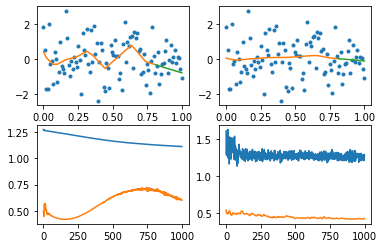

```python
net2.eval()
fig, ((ax1,ax2),(ax3,ax4)) = plt.subplots(2,2)
ax1.plot(X,y,'.'); ax1.plot(X1,net1(X1).data); ax1.plot(X2,net1(X2).data)
ax2.plot(X,y,'.'); ax2.plot(X1,net2(X1).data); ax2.plot(X2,net2(X2).data)
ax3.plot(tr_loss_net1); ax3.plot(val_loss_net1)
ax4.plot(tr_loss_net2); ax4.plot(val_loss_net2)
```

`-` 다 좋은데 코드짜는게 너무 스트레스 받음

- 생각해보니까 미니배치도 만들어야 함 + 미니배치 나눈상태에서 GPU에 메모리 올리는 코드도 처리해야 함
- 조기종료와 같은 기능도 구현해야함 + 기타등등의 기능을 구현해야 함
- 나중에는 학습률을 서로 다르게 돌려가며 결과도 기록해야 함 $\to$ 그래야 좋은 학습률 선택가능
- for 문안에 step1~step4 넣는것도 반복작업임
- 등등..

`-` 위와 같은 것들의 특징: 입으로 구현하기는 쉽지만 손으로 구현하기는 귀찮다.

`-` 사실 우리가 하고 싶은 것

- **아키텍처설계**: 데이터를 보고 우리가 해봐야 한다
- 손실함수: 통계학과 교수님들이 연구하심
- 옵티마이저: 산공교수님들이 연구하심

`-` 우리가 하고싶은것만 집중하고 하기싫은것은 구현된 코드로 넘기자!! (fastai + pytorch)

`-` 제 생각

- 기업의욕심: real-data를 분석하는 딥러닝 아키텍처를 설계 $\to$ 아키텍처별로 결과 관찰 (편하게) $\Longrightarrow$ fastai + real data
- 학생의욕심: 그러면서도 모형이 돌아가는 원리는 아무 세밀하게 알고 싶음 $\Longrightarrow$ pytorch + toy example (regression 위주로)
- 연구자의욕심: 기존의 모형을 조금 변경하여 쓰고싶음 $\Longrightarrow$ (fastai + pytorch) + any data

`-` **tensorflow + keras** vs **pytorch + fastai** $\to$ 나중에 올릴게요!

### pytorch + fastai

#### 사전준비

`-` 데이터셋을 만든다.

```python
X_tr=X[:80]
y_tr=y[:80]
X_val=X[80:]
y_val=y[80:]
```

```python
ds1=torch.utils.data.TensorDataset(X_tr,y_tr)
ds2=torch.utils.data.TensorDataset(X_val,y_val)
```

`-` 데이터로더를 만든다.

```python
dl1 = torch.utils.data.DataLoader(ds1,batch_size=80) # batch_size 강제설정안하면 자기가 알아서 나눔
dl2 = torch.utils.data.DataLoader(ds2,batch_size=20)
```

`-` 데이터로더스를 만든다

```python
from fastai.vision.all import *
```

```python
dls=DataLoaders(dl1,dl2)
```

#### 드랍아웃 제외버전

`-` 네트워크 설계 (드랍아웃제외)

```python
torch.manual_seed(1)
net_fastai= torch.nn.Sequential(
    torch.nn.Linear(1,512),
    torch.nn.ReLU(),
    #torch.nn.Dropout(0.8),
    torch.nn.Linear(512,1)
)
#optimizer=torch.optim.Adam(net.parameters())
loss_fn=torch.nn.MSELoss()
```

`-` 러너오브젝트 생성 (for문 대신돌려주는 오브젝트)

```python
lrnr = Learner(dls,net_fastai,opt_func=Adam,loss_func=loss_fn)
```

`-` 에폭만 설정하고 바로 학습

```python
lrnr.fit(1000)
```

| epoch | train_loss | valid_loss | time |
| --- | --- | --- | --- |
| 0 | 1.277156 | 0.491314 | 00:00 |
| 1 | 1.277145 | 0.455286 | 00:00 |
| 2 | 1.275104 | 0.444275 | 00:00 |
| 3 | 1.274429 | 0.465787 | 00:00 |
| 4 | 1.273436 | 0.507203 | 00:00 |
| 5 | 1.272421 | 0.548102 | 00:00 |
| 6 | 1.271840 | 0.561292 | 00:00 |
| 7 | 1.271377 | 0.549409 | 00:00 |
| 8 | 1.270855 | 0.530416 | 00:00 |
| 9 | 1.270437 | 0.520700 | 00:00 |
| 10 | 1.270176 | 0.526273 | 00:00 |
| 11 | 1.269935 | 0.543579 | 00:00 |
| 12 | 1.269655 | 0.562939 | 00:00 |
| 13 | 1.269411 | 0.571586 | 00:00 |
| 14 | 1.269217 | 0.563700 | 00:00 |
| 15 | 1.269018 | 0.543646 | 00:00 |
| 16 | 1.268787 | 0.521385 | 00:00 |
| 17 | 1.268563 | 0.505799 | 00:00 |
| 18 | 1.268362 | 0.500011 | 00:00 |
| 19 | 1.268159 | 0.501830 | 00:00 |
| 20 | 1.267941 | 0.506255 | 00:00 |
| 21 | 1.267730 | 0.506739 | 00:00 |
| 22 | 1.267540 | 0.499733 | 00:00 |
| 23 | 1.267353 | 0.487385 | 00:00 |
| 24 | 1.267163 | 0.474839 | 00:00 |
| 25 | 1.266981 | 0.466926 | 00:00 |
| 26 | 1.266814 | 0.465347 | 00:00 |
| 27 | 1.266648 | 0.468656 | 00:00 |
| 28 | 1.266480 | 0.473641 | 00:00 |
| 29 | 1.266316 | 0.476266 | 00:00 |

[output cut: 970 more lines]

`-` 결과도 알아서 기록되어 있음

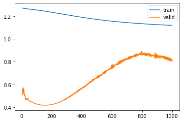

```python
lrnr.recorder.plot_loss()
```

`-` net_fastai에 파라메터가 업데이트 되어있음

- 확인해보면 GPU도 알아서 써놓음

`-` GPU에 있는것을 일단 CPU로 옮김

```python
net_fastai.to("cpu")
```

```
Sequential(
  (0): Linear(in_features=1, out_features=512, bias=True)
  (1): ReLU()
  (2): Linear(in_features=512, out_features=1, bias=True)
)
```

`-` 플랏

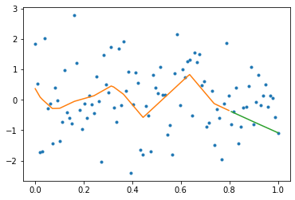

```python
plt.plot(X,y,'.')
plt.plot(X_tr,net_fastai(X_tr).data)
plt.plot(X_val,net_fastai(X_val).data)
```

#### 드랍아웃 추가버전

`-` 네트워크 설계 (드랍아웃추가)

```python
torch.manual_seed(1)
net_fastai= torch.nn.Sequential(
    torch.nn.Linear(1,512),
    torch.nn.ReLU(),
    torch.nn.Dropout(0.8),
    torch.nn.Linear(512,1)
)
#optimizer=torch.optim.Adam(net.parameters())
loss_fn=torch.nn.MSELoss()
```

`-` 러너오브젝트 생성 (for문 대신돌려주는 오브젝트)

```python
lrnr = Learner(dls,net_fastai,opt_func=Adam,loss_func=loss_fn)
```

`-` 에폭만 설정하고 바로 학습

```python
lrnr.fit(1000)
```

| epoch | train_loss | valid_loss | time |
| --- | --- | --- | --- |
| 0 | 1.585653 | 0.428918 | 00:00 |
| 1 | 1.552326 | 0.434847 | 00:00 |
| 2 | 1.568810 | 0.442775 | 00:00 |
| 3 | 1.543528 | 0.449585 | 00:00 |
| 4 | 1.562597 | 0.456666 | 00:00 |
| 5 | 1.523623 | 0.459943 | 00:00 |
| 6 | 1.506816 | 0.458130 | 00:00 |
| 7 | 1.510407 | 0.455353 | 00:00 |
| 8 | 1.532602 | 0.449054 | 00:00 |
| 9 | 1.528153 | 0.445443 | 00:00 |
| 10 | 1.518390 | 0.442207 | 00:00 |
| 11 | 1.508012 | 0.442086 | 00:00 |
| 12 | 1.498026 | 0.443293 | 00:00 |
| 13 | 1.502874 | 0.444508 | 00:00 |
| 14 | 1.502828 | 0.445713 | 00:00 |
| 15 | 1.496831 | 0.446047 | 00:00 |
| 16 | 1.483070 | 0.447462 | 00:00 |
| 17 | 1.496551 | 0.449803 | 00:00 |
| 18 | 1.482904 | 0.450663 | 00:00 |
| 19 | 1.471269 | 0.453689 | 00:00 |
| 20 | 1.467480 | 0.456816 | 00:00 |
| 21 | 1.457825 | 0.460537 | 00:00 |
| 22 | 1.450724 | 0.463197 | 00:00 |
| 23 | 1.445010 | 0.466199 | 00:00 |
| 24 | 1.441184 | 0.471516 | 00:00 |
| 25 | 1.436977 | 0.474600 | 00:00 |
| 26 | 1.431098 | 0.476256 | 00:00 |
| 27 | 1.423327 | 0.478671 | 00:00 |
| 28 | 1.416092 | 0.479825 | 00:00 |
| 29 | 1.414993 | 0.478338 | 00:00 |

[output cut: 970 more lines]

`-` 결과도 알아서 기록되어 있음

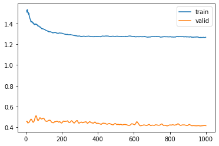

```python
lrnr.recorder.plot_loss()
```

`-` net_fastai에 파라메터가 업데이트 되어있음

- 확인해보면 GPU도 알아서 써놓음

`-` GPU에 있는것을 일단 CPU로 옮김

```python
net_fastai.to("cpu")
```

```
Sequential(
  (0): Linear(in_features=1, out_features=512, bias=True)
  (1): ReLU()
  (2): Dropout(p=0.8, inplace=False)
  (3): Linear(in_features=512, out_features=1, bias=True)
)
```

`-` 플랏

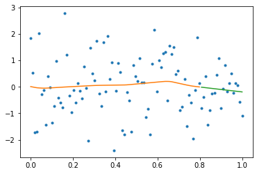

```python
plt.plot(X,y,'.')
plt.plot(X_tr,net_fastai(X_tr).data)
plt.plot(X_val,net_fastai(X_val).data)
```

### CPU vs GPU 시간비교

```python
import time
```

#### CPU (512)

```python
torch.manual_seed(5)
X=torch.linspace(0,1,100).reshape(100,1)
y=torch.randn(100).reshape(100,1)*0.01
```

```python
torch.manual_seed(1) # 초기가중치를 똑같이..
net= torch.nn.Sequential(
    torch.nn.Linear(1,512),
    torch.nn.ReLU(),
    torch.nn.Linear(512,1))
optimizer= torch.optim.Adam(net.parameters())
loss_fn=torch.nn.MSELoss()
```

```python
t1=time.time()
for epoc in range(1000):
    ## 1
    yhat= net(X)
    ## 2
    loss=loss_fn(yhat,y)
    ## 3
    loss.backward()
    ## 4
    optimizer.step()
    net.zero_grad()
t2=time.time()
```

```python
t2-t1
```

```
0.5149078369140625
```

#### GPU (512)

```python
torch.manual_seed(5)
X=torch.linspace(0,1,100).reshape(100,1)
y=torch.randn(100).reshape(100,1)*0.01
```

```python
torch.manual_seed(1) # 초기가중치를 똑같이..
net= torch.nn.Sequential(
    torch.nn.Linear(1,512),
    torch.nn.ReLU(),
    torch.nn.Linear(512,1))
optimizer= torch.optim.Adam(net.parameters())
loss_fn=torch.nn.MSELoss()
```

```python
net.to("cuda:0")
X=X.to("cuda:0")
y=y.to("cuda:0")
```

```python
t1=time.time()
for epoc in range(1000):
    ## 1
    yhat= net(X)
    ## 2
    loss=loss_fn(yhat,y)
    ## 3
    loss.backward()
    ## 4
    optimizer.step()
    net.zero_grad()
t2=time.time()
```

```python
t2-t1
```

```
1.757263422012329
```

`-` ?? CPU가 더 빠르다!

#### CPU (2048)

```python
torch.manual_seed(5)
X=torch.linspace(0,1,100).reshape(100,1)
y=torch.randn(100).reshape(100,1)*0.01
```

```python
torch.manual_seed(1) # 초기가중치를 똑같이..
net= torch.nn.Sequential(
    torch.nn.Linear(1,2048),
    torch.nn.ReLU(),
    torch.nn.Linear(2048,1))
optimizer= torch.optim.Adam(net.parameters())
loss_fn=torch.nn.MSELoss()
```

```python
t1=time.time()
for epoc in range(1000):
    ## 1
    yhat= net(X)
    ## 2
    loss=loss_fn(yhat,y)
    ## 3
    loss.backward()
    ## 4
    optimizer.step()
    net.zero_grad()
t2=time.time()
```

```python
t2-t1
```

```
0.7874736785888672
```

#### GPU (2048)

```python
torch.manual_seed(5)
X=torch.linspace(0,1,100).reshape(100,1)
y=torch.randn(100).reshape(100,1)*0.01
```

```python
torch.manual_seed(1) # 초기가중치를 똑같이..
net= torch.nn.Sequential(
    torch.nn.Linear(1,2048),
    torch.nn.ReLU(),
    torch.nn.Linear(2048,1))
optimizer= torch.optim.Adam(net.parameters())
loss_fn=torch.nn.MSELoss()
```

```python
net.to("cuda:0")
X=X.to("cuda:0")
y=y.to("cuda:0")
```

```python
t1=time.time()
for epoc in range(1000):
    ## 1
    yhat= net(X)
    ## 2
    loss=loss_fn(yhat,y)
    ## 3
    loss.backward()
    ## 4
    optimizer.step()
    net.zero_grad()
t2=time.time()
```

```python
t2-t1
```

```
1.6859557628631592
```

`-` 좁혀진다..

#### CPU (204800)

```python
torch.manual_seed(5)
X=torch.linspace(0,1,100).reshape(100,1)
y=torch.randn(100).reshape(100,1)*0.01
```

```python
torch.manual_seed(1) # 초기가중치를 똑같이..
net= torch.nn.Sequential(
    torch.nn.Linear(1,204800),
    torch.nn.ReLU(),
    torch.nn.Linear(204800,1))
optimizer= torch.optim.Adam(net.parameters())
loss_fn=torch.nn.MSELoss()
```

```python
t1=time.time()
for epoc in range(1000):
    ## 1
    yhat= net(X)
    ## 2
    loss=loss_fn(yhat,y)
    ## 3
    loss.backward()
    ## 4
    optimizer.step()
    net.zero_grad()
t2=time.time()
```

```python
t2-t1
```

```
63.12169361114502
```

```python
torch.manual_seed(5)
X=torch.linspace(0,1,100).reshape(100,1)
y=torch.randn(100).reshape(100,1)*0.01
```

```python
torch.manual_seed(1) # 초기가중치를 똑같이..
net= torch.nn.Sequential(
    torch.nn.Linear(1,204800),
    torch.nn.ReLU(),
    torch.nn.Linear(204800,1))
optimizer= torch.optim.Adam(net.parameters())
loss_fn=torch.nn.MSELoss()
```

```python
net.to("cuda:0")
X=X.to("cuda:0")
y=y.to("cuda:0")
```

```python
t1=time.time()
for epoc in range(1000):
    ## 1
    yhat= net(X)
    ## 2
    loss=loss_fn(yhat,y)
    ## 3
    loss.backward()
    ## 4
    optimizer.step()
    net.zero_grad()
t2=time.time()
```

```python
t2-t1
```

```
2.2001500129699707
```